# Lista de Exercícios – Unidade 2

#### 1) Os diâmetros de oito mancais selecionados ao acaso são os seguintes (em mm):

```r
diametro <- c(50.001, 50.002, 49.998, 50.006, 50.005, 49.996, 50.003, 50.004)
```

- 1. Calcule a média amostral.

```r
mean(diametro)
```

```
## [1] 50.00187
```

- 2. Calcule o desvio-padrão amostral.

```r
sd(diametro)
```

```
## [1] 0.003440826
```

#### 2) O tempo de vida até falhar em horas de um componente eletrônico sujeito a um teste de durabilidade acelerado é mostrado abaixo para uma amostra com tamanho n = 40. Para acelerar a falha no teste, as unidades experimentais são testadas sob uma temperatura elevada.

```r
tempo <- c(127, 125, 131, 124, 129, 121, 142, 151, 160, 125,
           124, 123, 120, 119, 128, 133, 137, 124, 142, 123,
           121, 136, 140, 137, 125, 124, 128, 129, 130, 122,
           118, 131, 125, 133, 141, 125, 140, 132, 129, 126)
```

- 1. Calcule a média amostral e o desvio-padrão.

```r
mean(tempo)
```

```
## [1] 130
```

```r
sd(tempo)
```

```
## [1] 8.918434
```

- 2. Construa o histograma.

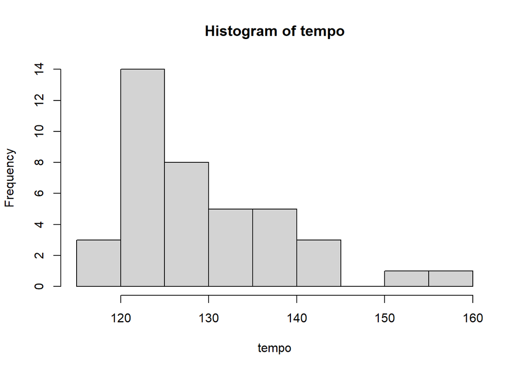

```r
hist(tempo)
```

- 3. Ache a mediana e os quartis.

```r
quantile(tempo,c(0.25,0.50,0.75))
```

```
##    25%    50%    75%
## 124.00 128.00 133.75
```

#### 3) Os dados abaixo são leituras do rendimento de um processo químico em dias sucessivos (leia da esquerda para a direita). Faça o histograma dos dados, comente o aspecto do histograma e verifique se o histograma lembra alguma distribuição de probabilidade conhecida.

```r
dados <- c(94.1, 87.3, 94.1, 92.4, 84.6, 85.4, 93.2, 84.1, 92.1, 90.6,
           83.6, 86.6, 90.6, 90.1, 96.4, 89.1, 85.4, 91.7, 91.4, 95.2,
           88.2, 88.8, 89.7, 87.5, 88.2, 86.1, 86.4, 86.4, 87.6, 84.2,
           86.1, 94.3, 85.0, 85.1, 85.1, 85.1, 95.1, 93.2, 84.9, 84.0,
           89.6, 90.5, 90.0, 86.7, 87.3, 93.7, 90.0, 95.6, 92.4, 83.0,
           89.6, 87.7, 90.1, 88.3, 87.3, 95.3, 90.3, 90.6, 94.3, 84.1,
           86.6, 94.1, 93.1, 89.4, 97.3, 83.7, 91.2, 97.8, 94.6, 88.6,
           96.8, 82.9, 86.1, 93.1, 96.3, 84.1, 94.4, 87.3, 90.4, 86.4,
           94.7, 82.6, 96.1, 86.4, 89.1, 87.6, 91.1, 83.1, 98.0, 84.5)
```

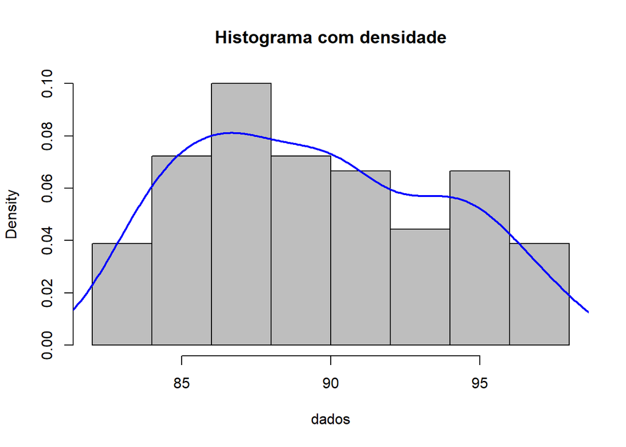

```r
hist(dados, probability = TRUE, col = "gray", border = "black", main = "Histograma com densidade")
lines(density(dados), col = "blue", lwd = 2)  # Adiciona a curva de densidade estimada
```

#### 4) Considere o rendimento do processo químico do exercício anterior. Calcule a média amostral e o desvio padrão.

```r
mean(dados)
```

```
## [1] 89.47556
```

```r
sd(dados)
```

```
## [1] 4.157768
```

#### 5) Suponha que dois dados não viciados são lançados e uma variável aleatória observada, digamos X, que corresponde a soma das duas faces superiores. Descreva o espaço amostral do experimento e determine a

função de probabilidade da v.a. X.

```r
dados <- expand.grid(1:6,1:6)

X <- apply(dados,1,sum)

fdp <- table(X)/length(X)

fdp
```

```
## X
##          2          3          4          5          6          7          8
## 0.02777778 0.05555556 0.08333333 0.11111111 0.13888889 0.16666667 0.13888889
##          9         10         11         12
## 0.11111111 0.08333333 0.05555556 0.02777778
```

#### 7) Calculadoras eletrônicas são classificadas ao final de um trabalho de inspeção. Três tipos de nãoconformidade podem ocorrer nas calculadoras: crítica, maior e menor. A experiência tem indicado que os

defeitos ocorrem da maneira seguinte:

(A)críticos 1,5% | (B)maiores 1,0% | (C)menores 2,0% | (A∩B)ambos crítico e maior 0,2% | (A∩C)ambos crítico e menor 0,8% | (B∩C)ambos maior e menor 0,5% | (A∩B∩C)os três defeitos 0,1%

###### a) Qual a porcentagem da produção que estão de acordo com as especificações de projeto?

- A U B U C = A + B + C - A∩B - A∩C - B∩C + A∩B∩C // A U B U C = 1.5 + 1 + 2 - 0.2 - 0.8 - 0.5 + 0.1 = 3.1. Temos 3,1% de peças defeituosas, logo 96,9% estão de acordo.

###### b) Calculadoras que tem defeito crítico ou defeito crítico e outro tipo de defeito devem ser jogados fora. Qual a porcentagem da produção jogada fora?

- 1,5% das peças devem ser jogadas fora.

###### c) Calculadoras com defeito maior ou menor ou ambos devem ser consertados. Qual a porcentagem da

produção sujeita a retrabalho?

- O resultado seria todas exceto as com defeito crítico isolado. O total de peças com apenas defeito crítico pode ser representado por A - A∩B - A∩C + A∩B∩C = 1,5 - 0,2 - 0,8 + 0,1. logo a porcentagem sujeita a retrabalho é de 3,1% - 0,6 % = **2,5 %**